# Sample script for analyzing SYTOX flow cytometry data

Bin He

2024-12-26 (updated 2024-12-27 14:55:54.00264)

> *Note*: modify the title, author and date taglines above as necessary. the other settings can be changed if you know what they are for.

Load libraries

```r
require(tidyverse)
require(flowCore)
require(flowClust)
require(openCyto)
require(ggcyto)
require(ggridges)
require(cowplot)
```

Set themes for ggplot. If you prefer a different default plot setting, change here.

# Goal

- Analyze SYTOX flow cytometry data to see if we can distinguish G0 from G1, S and G2 phase cells
- provide an example for Jess to use for future analyses

# Data

First, we specify the path to where the FCS files are stored. I’m using “relative path” here, with “../” meaning the folder above the current one where this script is stored. This is preferred over “absolute path” such as “~/Documents/work/current/…” or “C:”

Once the folder is specified, the following lines of code read in all the FCS files in that folder into a “list” object named “fs” (you can change the name to anything you want, provided that it conforms to the naming convention of the R language, like no spaces or exclamation point).

```r
#sample <- read.csv("20230223-sample-list.csv") %>% column_to_rownames(var = "file")
data.path = "../input/20240522-aged-Sc-cells/"
fs <- read.flowSet(path = data.path, pattern = ".fcs", # specify the file pattern
                   # the original values are already linearized.
                   transformation = FALSE,
                   # change parameter names to R format
                   emptyValue = FALSE,  alter.names = TRUE,
                   # only load the height variables for the fluorescent parameters
                   column.pattern = ".H|FSC|SSC")
```

Note that I’ve “standardized” file names so that I can extract necessary “meta information” from them. Alternatively, you can write a separate “sample info” file that is loaded separately. For the filename method to work, they have to follow a consistent format with fixed separators (I use “-”).

```r
# extract the file names
oriNames <- sampleNames(fs)
# set column names
col_names <- expression(date, treatment, dye, strain, time, rep) %>%
  as.character() # this specifies the column names
# split the file names by "-" and assign them to individual columns
sample <- data.frame(name = oriNames) %>%
  separate(name, into = col_names, sep = "-") %>%
  mutate(rep = str_replace_all(rep, "rep|.fcs", ""),
         name = paste(time, rep, sep = "-"))
rownames(sample) <- oriNames
# set the meta data. note that the order of the filenames match the tibble
# order.
pData(fs) <- sample
```

2. Recovery time course

```r
data.path = "../input/20241218-time-course/"
fs1 <- read.flowSet(path = data.path, pattern = ".fcs", # specify the file pattern
                    # the original values are already linearized.
                    transformation = FALSE,
                    # change parameter names to R format
                    emptyValue = FALSE,  alter.names = TRUE,
                    # only load the height variables for the fluorescent parameters
                    column.pattern = ".H|FSC|SSC")
```

Note that I’ve “standardized” file names so that I can extract necessary “meta information” from them. Alternatively, you can write a separate “sample info” file that is loaded separately. For the filename method to work, they have to follow a consistent format with fixed separators (I use “-”).

```r
# extract the file names
oriNames1 <- sampleNames(fs1)
# set column names
col_names1 <- expression(strain, time, rep) %>%
  as.character() # this specifies the column names
# split the file names by "-" and assign them to individual columns
sample1 <- data.frame(date = "20241218", treatment = "recovery", dye = "SYTOX",
                      name = oriNames1) %>%
  separate(name, into = col_names1, sep = "-") %>%
  mutate(rep = str_replace_all(rep, "rep|.fcs", ""),
         time = str_replace(time, "_", ":"),
         name = paste(time, rep, sep = "_"))
         #time = hm(time)) # convert to a period object)
rownames(sample1) <- oriNames1
# set the meta data. note that the order of the filenames match the tibble
# order.
pData(fs1) <- sample1
```

# Aged cells

Here we read in the FCS files directly, perform gating and QC before extracting the desired stats (usually MFI) for export and further analyses.

## Gating: -outlier

Next we use a series of plots to guide our gating strategy for identifying the population we want to work with.

We first gate on FSC.H and SSC.H to remove outliers (events that are too big or too small). The Attune instrument we use can record six decades (10<sup>0-10</sup>6), with the first two decades mostly occupied by electronic noise.

Let’s first define a gate and visualize it in a plot before adding it to a GatingSet.

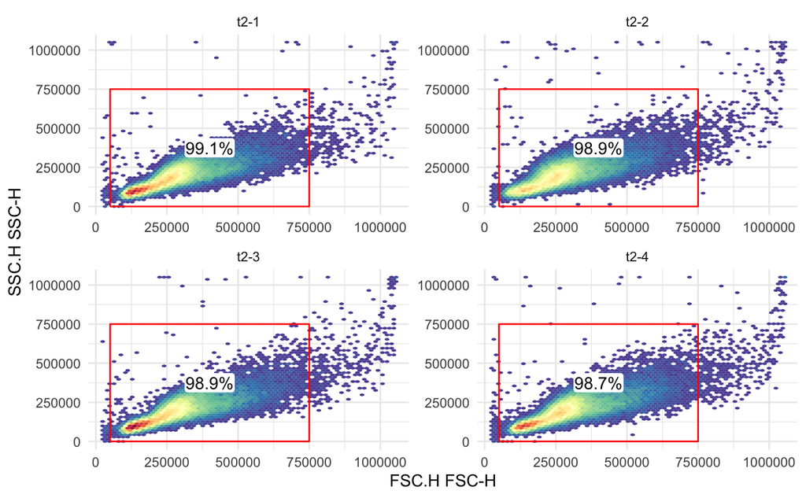

```r
outlier.gate <- rectangleGate(filterId = "-outlier",
                              "FSC.H" = c(0.5e5, 0.75e6),
                              "SSC.H" = c(1e2, 0.75e6))
ggcyto(fs[sample(1:10, 4)], aes(x = FSC.H, y = SSC.H), subset = "root") +
  geom_hex(bins = 64) + geom_gate(outlier.gate) + geom_stats()
```

Add this gate to the GatingSet

```r
gs <- GatingSet(fs) # create a GatingSet
gs_pop_add(gs, outlier.gate, parent = "root")
```

```
[1] 2
```

```r
recompute(gs)
```

```
done!
```

## Gating: Singlet

Next let’s remove multiplets on FSC.H vs FSC.W. To do this, we could either manually set up a polygon gate, or use the automatic clustering function provided by the `flowClust` package. Note that in the original implementation, the `flowClust()` function or the `tmixFilter()` version that was supposed to allow for integration with the `flowCore` package, both were designed with different downstream actions in mind than what I want to do here (visualize with `ggcyto() + geom_gate()`). The `openCyto` package written by the same group of authors who created `flowClust` and `ggcyto` has a helper function to make this possible. See [this post](https://support.bioconductor.org/p/96945/) for a discussion on alternative ways to achieve this.

*Update* switch to a polygon gate as the clustering is not working well. *Update 2023/10/11* visualize how the two populations differ in fluorescence

**FSC.H vs FSC.W plot**

[output not shown]

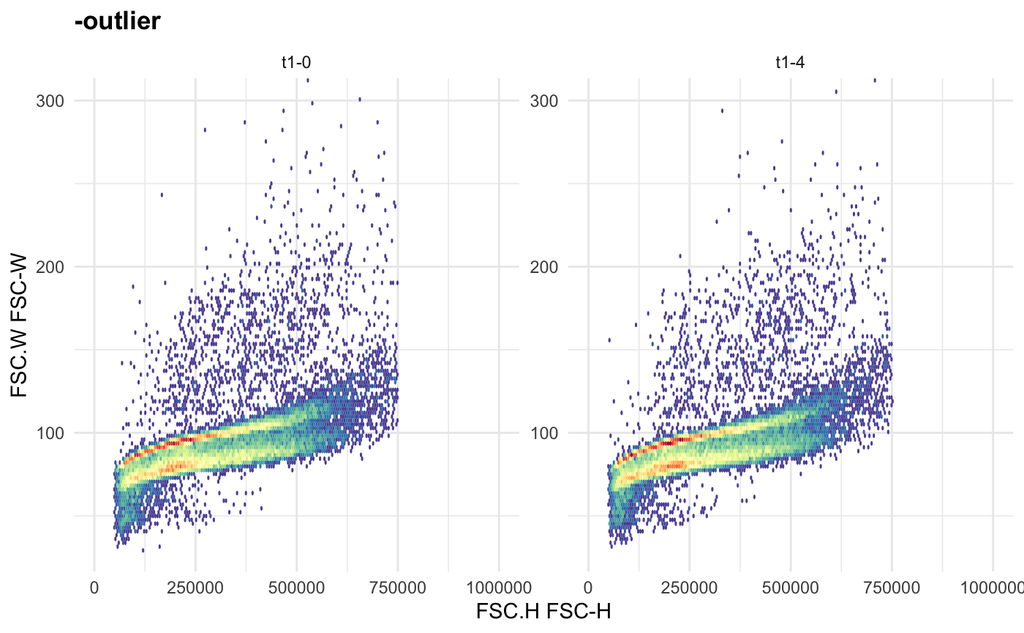

```r
scPars <- ggcyto_par_set(limits = list(x = c(0,1e6), y = c(30,300)))
ggcyto(gs[sample(1:10,2)], aes(x = FSC.H, y = FSC.W), subset = "-outlier") +
  geom_hex(bins = 128) + scPars
```

> There is clearly a second population with the same FSC.H but higher FSC.W, indicative of doublets presence. The diffused population further to the upper right likely represent multiplets, since they have a steeper slope, indicating an increase in width without significant change in peak height

Is it necessary to gate out the doublets and multiplets? We can separate the singlets from the rest and compare their fluorescence readings

```r
#singlet.gate <- gate_flowclust_2d(ex, "FSC.H", "FSC.W", filterId = "singlet", K = 2, quantile = 0.8)
# switch to a polygongate
polygon <- matrix(c(0.5e5, 0.5e5, 0.75e6, 0.75e6, 60, 75, 120,60), ncol = 2)
colnames(polygon) <- c("FSC.H", "FSC.W")
singlet.gate <- polygonGate(filterId = "singlet", .gate = polygon)
```

```r
# use one sample for test. start by generating a filtered result
tmp <- fs[[1]]
tmp.ff <- filter(tmp, singlet.gate)
histPars <- ggcyto_par_set(limits = list(x = c(1e3,1e5)))
p.list <- list(
  scale_x_logicle(),
  scale_fill_discrete("Singlet", labels = c("NO", "YES")),
  theme(legend.position = "top")
)
p1 <- ggcyto(tmp, aes(x = FSC.H, y = FSC.W)) + geom_hex(bins = 80) + scPars +
  geom_gate(singlet.gate) +  geom_stats(type = c("percent", "count"), adjust = c(0.8, 0.2))
```

[output not shown]

```r
p2 <- ggcyto(tmp, aes(x = `BL1.H`)) +
  geom_density(aes(color = tmp %in% tmp.ff), fill = NA) +
  scale_color_brewer("Singlet", type = "qual", palette = 2) +
  p.list + histPars
```

[output not shown]

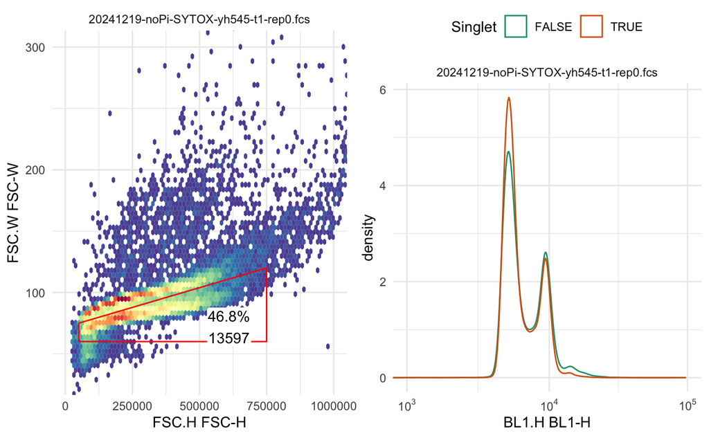

```r
#p3 <- ggplot(tmp, aes(x = `YL2.H`)) + geom_density(aes(fill = tmp %in% tmp.ff), alpha = 0.5) + p.list
#p.col <- plot_grid(p2, p3 + theme(legend.position = "none"), nrow = 2)
plot_grid(as.ggplot(p1), as.ggplot(p2))
```

> there are not obvious differences between the two subpopulations

Add this gate to the gatingSet

```r
gs_pop_add(gs, singlet.gate, parent = "-outlier", name = "singlet")
```

```
[1] 3
```

```r
recompute(gs)
```

```
done!
```

[output not shown]

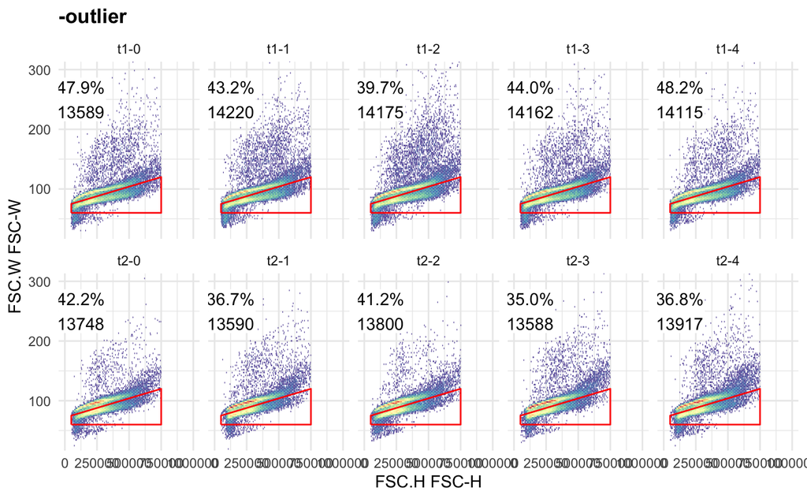

```r
ggcyto(gs, aes(x = FSC.H, y = FSC.W), subset = "-outlier") +
  geom_hex(bins = 128) + geom_gate("singlet") +
  facet_wrap(~name, ncol = 5)+ scPars +
  geom_stats(type = c("percent", "count"), location = "fixed", adjust = c(125e3, 250))
```

## Data plotting

The code below demonstrates how to subset a flowSet, how to apply logicle (or other) transformations in ggcyto() (not on the original dataset)

```r
#histPars <- ggcyto_par_set(limits = list(x = c(1e3,1e5)))
p1 <- ggcyto(gs, aes(x = `BL1.H`), subset = "singlet") +
  geom_density_ridges(aes(y = time,fill = time), alpha = 0.5) +
  scale_x_logicle() + # use logical transformation on the fluorescence value
  histPars + facet_wrap(~rep)
```

[output not shown]

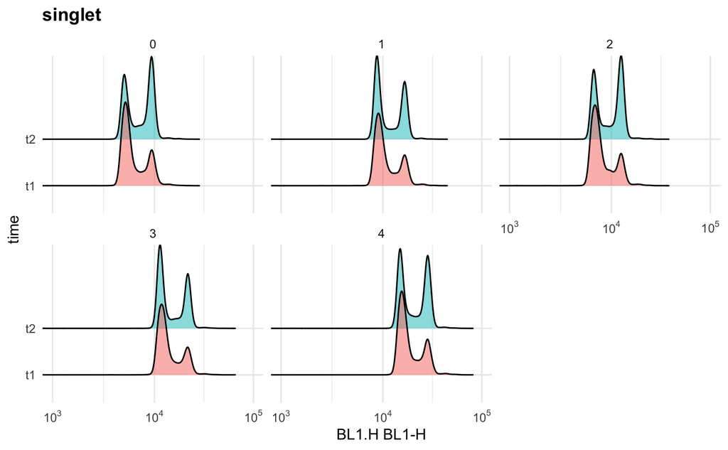

```r
p1
```

```r
#p2 <- ggplot(fs[test], aes(x = `YL2.H`)) + geom_density_ridges(aes(y = name, fill = name)) + scale_x_logicle()
#theme.elements <- list(
#  theme_cowplot(),
#  theme(legend.position = "none", axis.title.y = element_blank(), axis.text.y = element_blank())
#)
#plot_grid(p1 + theme.elements, p2 + theme.elements + theme(legend.position = c(0.6, 0.85)), ncol = 2)
```

> We can see the change in G0/G1 to G2, but not enough resolution to visualize the S phase or to separate G0 from G1 .

# Recovery time course

## Gating: -outlier

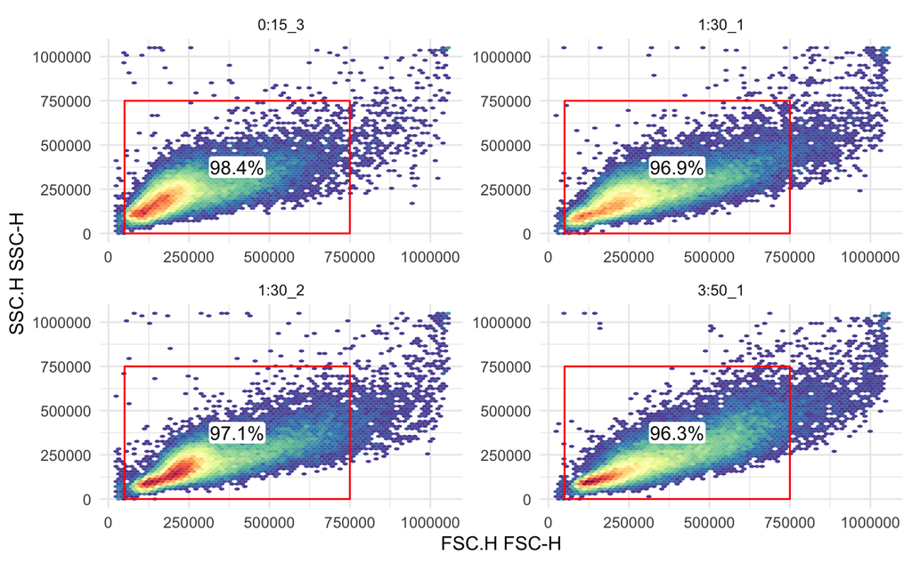

```r
#outlier.gate <- rectangleGate(filterId = "-outlier",
#                              "FSC.H" = c(0.5e5, 0.75e6),
#                              "SSC.H" = c(1e2, 0.75e6))
ggcyto(fs1[sample(1:10, 4)], aes(x = FSC.H, y = SSC.H), subset = "root") +
  geom_hex(bins = 64) + geom_gate(outlier.gate) + geom_stats()
```

```r
gs1 <- GatingSet(fs1) # create a GatingSet
gs_pop_add(gs1, outlier.gate, parent = "root")
```

```
[1] 2
```

```r
recompute(gs1)
```

```
done!
```

## Gating: Singlet

[output not shown]

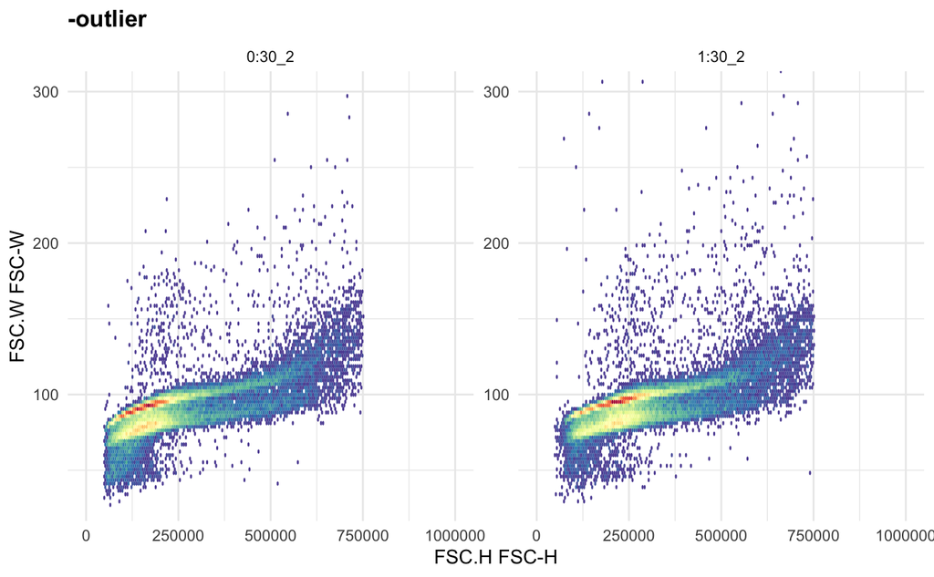

```r
ggcyto(gs1[sample(1:10,2)], aes(x = FSC.H, y = FSC.W), subset = "-outlier") +
  geom_hex(bins = 128) + scPars
```

> There is clearly a second population with the same FSC.H but higher FSC.W, indicative of doublets presence. The diffused population further to the upper right likely represent multiplets, since they have a steeper slope, indicating an increase in width without significant change in peak height

```r
#scPars <- ggcyto_par_set(limits = list(x = c(0,1e6), y = c(30,300)))
#polygon <- matrix(c(0.5e5, 0.5e5, 0.75e6, 0.75e6, 60, 75, 120,60), ncol = 2)
#colnames(polygon) <- c("FSC.H", "FSC.W")
#singlet.gate <- polygonGate(filterId = "singlet", .gate = polygon)
```

```r
# use one sample for test. start by generating a filtered result
tmp <- fs1[[1]]
tmp.ff <- filter(tmp, singlet.gate)
p.list <- list(
  scale_x_logicle(),
  scale_fill_discrete("Singlet", labels = c("NO", "YES")),
  theme(legend.position = "top")
)
p1 <- ggcyto(tmp, aes(x = FSC.H, y = FSC.W)) + geom_hex(bins = 80) + scPars +
  geom_gate(singlet.gate) +  geom_stats(type = c("percent", "count"), adjust = c(0.8, 0.2))
```

[output not shown]

```r
p2 <- ggcyto(tmp, aes(x = `BL1.H`)) +
  geom_density(aes(color = tmp %in% tmp.ff), fill = NA) +
  scale_color_brewer("Singlet", type = "qual", palette = 2) +
  p.list + histPars
```

[output not shown]

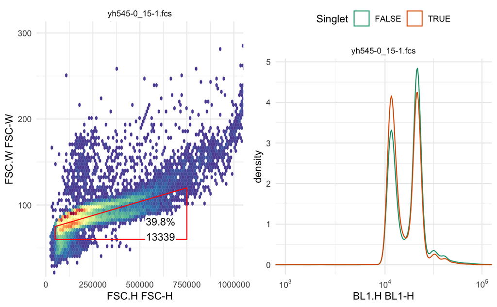

```r
#p3 <- ggplot(tmp, aes(x = `YL2.H`)) + geom_density(aes(fill = tmp %in% tmp.ff), alpha = 0.5) + p.list
#p.col <- plot_grid(p2, p3 + theme(legend.position = "none"), nrow = 2)
plot_grid(as.ggplot(p1), as.ggplot(p2))
```

> the multilet population has a higher fraction of high SYTOX stain events

```r
gs_pop_add(gs1, singlet.gate, parent = "-outlier", name = "singlet")
```

[output not shown]

[output not shown]

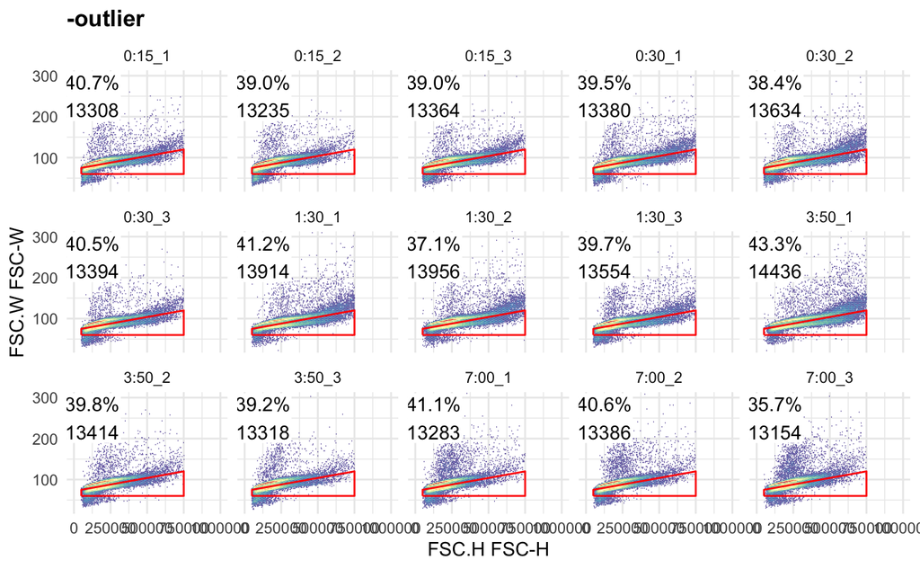

```r
ggcyto(gs1, aes(x = FSC.H, y = FSC.W), subset = "-outlier") +
  geom_hex(bins = 128) + geom_gate("singlet") +
  facet_wrap(~name, ncol = 5)+ scPars +
  geom_stats(type = c("percent", "count"), location = "fixed", adjust = c(125e3, 250))
```

## Data plotting

```r
histPars <- ggcyto_par_set(limits = list(x = c(1e3,1e5)))
p1 <- ggcyto(gs1, aes(x = `BL1.H`), subset = "singlet") +
  geom_density_ridges(aes(y = time,fill = time), alpha = 0.5) +
  scale_x_logicle() + # use logical transformation on the fluorescence value
  histPars + facet_wrap(~rep)
```

[output not shown]

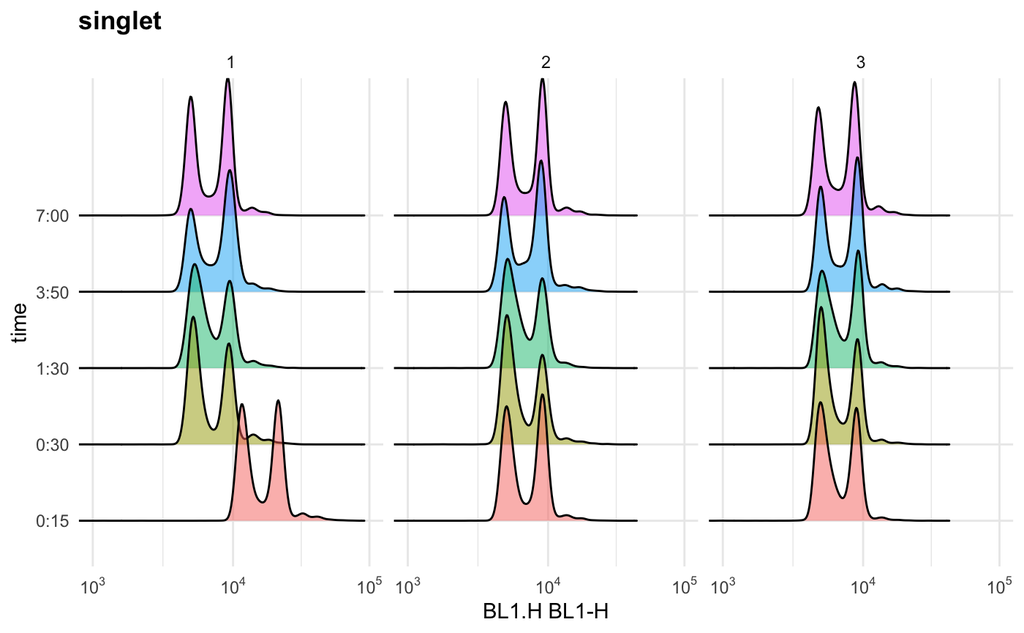

```r
p1
```

```r
#p2 <- ggplot(fs[test], aes(x = `YL2.H`)) + geom_density_ridges(aes(y = name, fill = name)) + scale_x_logicle()
#theme.elements <- list(
#  theme_cowplot(),
#  theme(legend.position = "none", axis.title.y = element_blank(), axis.text.y = element_blank())
#)
#plot_grid(p1 + theme.elements, p2 + theme.elements + theme(legend.position = c(0.6, 0.85)), ncol = 2)
```

> We can see the change in G0/G1 to G2, but not enough resolution to visualize the S phase or to separate G0 from G1 .